# DS2 Lab2 - Tree-based methods

Data Science 2: Machine Learning Tools - CEU 2021

Janos K. Divenyi, Jeno Pal

2021-03-01

```r
library(tidyverse)
library(ggplot2)
theme_set(theme_minimal())

library(h2o)
h2o.init()
```

[output not shown]

[output cut: 215 more lines]

[output not shown]

```
[1] 0.3303879
```

```r
h2o.mae(h2o.performance(simple_rf, data_valid))
```

```
[1] 0.3482789
```

Tune the random forest

```r
rf_grid <- h2o.grid(
  "randomForest", x = X, y = y,
  training_frame = data_train,
  grid_id = "rf",
  nfolds = 5,  # not absolutely necessary, as the optimization could be done on OOB samples as well
  seed = my_seed,
  hyper_params = rf_params
)
rf_grid <- h2o.grid(
  "randomForest", x = X, y = y,
  training_frame = data_train,
  grid_id = "rf",
  nfolds = 5,  # not absolutely necessary, as the optimization could be done on OOB samples as well
  seed = my_seed,
  hyper_params = rf_params
)
h2o.getGrid(rf_grid@grid_id, "mae")
```

```
H2O Grid Details
================

Grid ID: rf
Used hyper parameters:
  -  max_depth
  -  mtries
  -  ntrees
  -  sample_rate
Number of models: 96
Number of failed models: 0

Hyper-Parameter Search Summary: ordered by increasing mae
```

|  | max_depth | mtries | ntrees | sample_rate | model_ids | mae |
| --- | --- | --- | --- | --- | --- | --- |
| 1 | 20 | 2 | 100 | 1.0 | rf_model_82 | 0.3112930911481381 |
| 2 | 10 | 2 | 100 | 1.0 | rf_model_81 | 0.3117321774959564 |
| 3 | 20 | 2 | 300 | 1.0 | rf_model_90 | 0.3136143845121065 |
| 4 | 10 | 2 | 300 | 1.0 | rf_model_89 | 0.3136683264672756 |
| 5 | 10 | 2 | 300 | 0.632 | rf_model_57 | 0.3156037856737773 |

|  | max_depth | mtries | ntrees | sample_rate | model_ids | mae |
| --- | --- | --- | --- | --- | --- | --- |
| 91 | 10 | 6 | 10 | 0.2 | rf_model_5 | 0.3750535812973976 |
| 92 | 20 | 6 | 10 | 0.2 | rf_model_6 | 0.37505358159542085 |
| 93 | 20 | 4 | 10 | 0.2 | rf_model_4 | 0.3755835476517676 |
| 94 | 10 | 4 | 10 | 0.2 | rf_model_3 | 0.3755921098589896 |
| 95 | 10 | 2 | 10 | 0.2 | rf_model_1 | 0.3954555109143258 |
| 96 | 20 | 2 | 10 | 0.2 | rf_model_2 | 0.3955367118120193 |

```r
best_rf <- h2o.getModel(
  h2o.getGrid(rf_grid@grid_id, "mae")@model_ids[[1]]
)
h2o.mae(h2o.performance(best_rf))
```

```
[1] "NaN"
```

```r
best_rf <- h2o.getModel(
  h2o.getGrid(rf_grid@grid_id, "mae")@model_ids[[1]]
)
h2o.mae(h2o.performance(best_rf))
```

```
[1] "NaN"
```

```r
h2o.mae(h2o.performance(best_rf, data_valid))
```

```
[1] 0.3356916
```

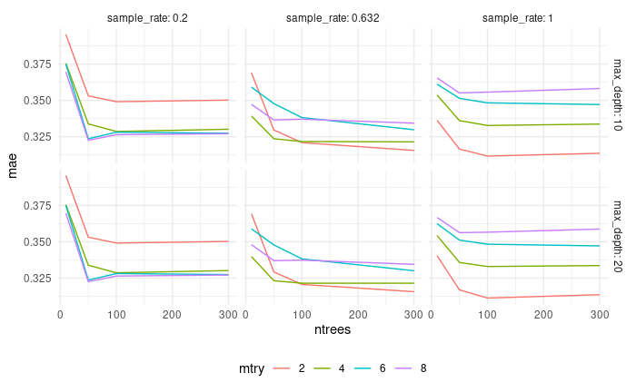

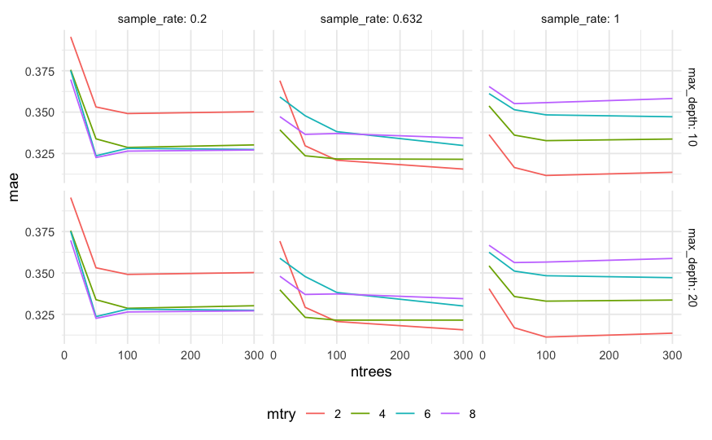

### Variable importance

With the ensemble models we have a hard time with interpretation. Variable importance measures can help to see which features contribute most to the predictive power of models. Variable importance is determined by calculating the relative influence of each variable: whether that variable was selected to split on during the tree building process, and how much the squared error (over all trees) improved (decreased) as a result.

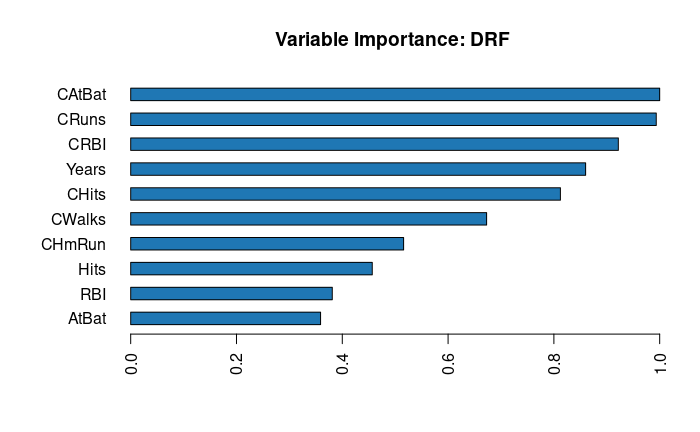

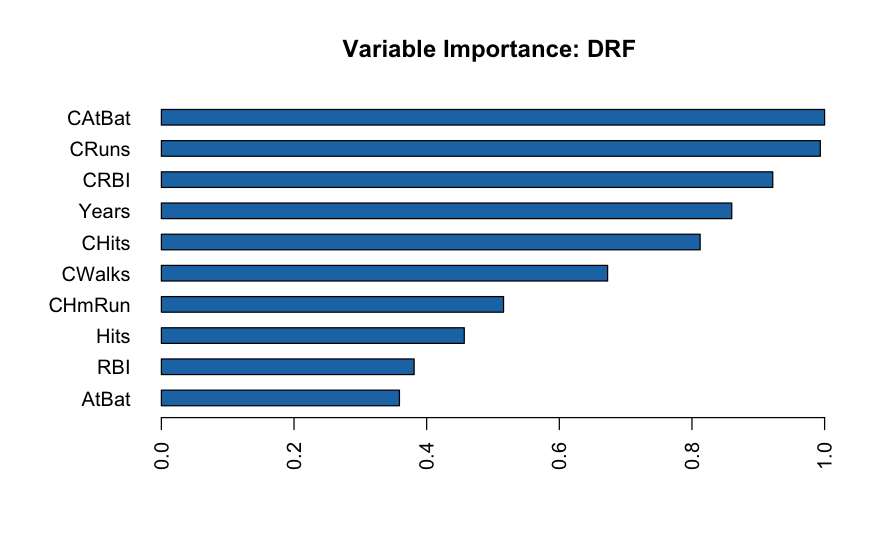

### Partial dependence

[figure not shown]

```
h2o.pd_plot(best_rf, data_valid, "CRuns")
```

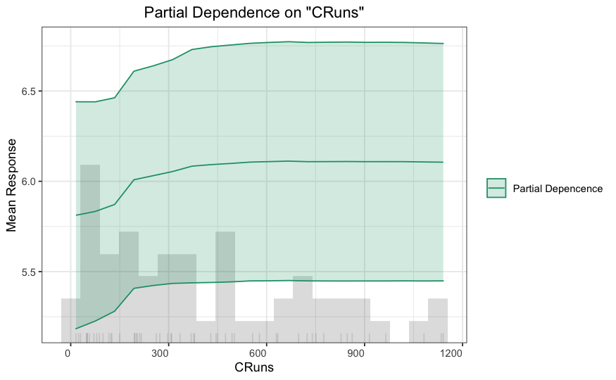

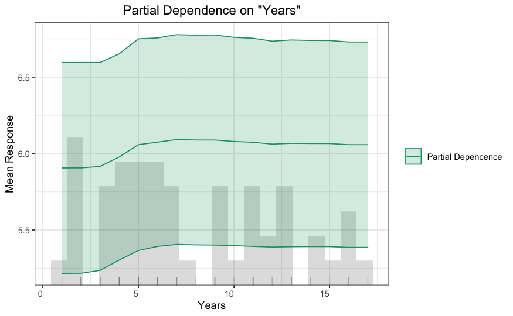

```r
h2o.pd_plot(best_rf, data_valid, "Years")
```

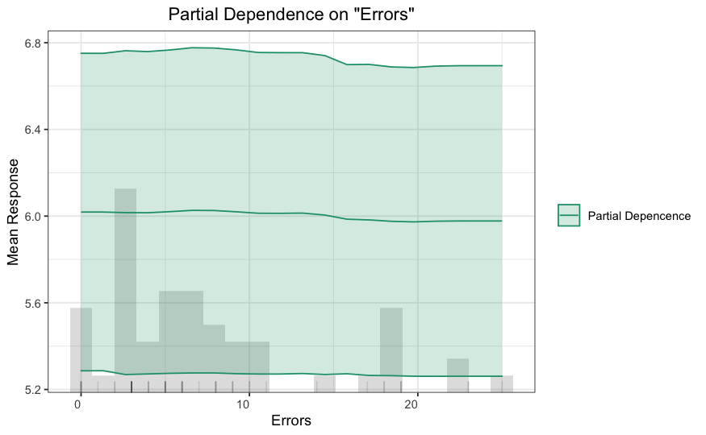

```r
h2o.pd_plot(best_rf, data_valid, "Errors")
```

I advise you to look at the [Model Explainability](https://docs.h2o.ai/h2o/latest-stable/h2o-docs/explain.html#) section of H2O’s documentation to see other tools that help you understand your model predictions.